# Estudo de Liberdade Economica sob corrupção

2024-09-17

Para esse trabalho, foi-se utilizado as base de dados do Index of Economic Freedom, juntamente com a base de dados do Corruption Perception Index.

As base de dados foram lidas, limpas, unidas e analisadas a partir dos scripts abaixo.

Index of Economic Freedom Disponivel em: https://www.heritage.org/index/pages/all-country-scores Acesso em 20 de setembro de 2024

Corruption Perception Index Disponivel em: https://www.transparency.org/en/cpi/2023/ Acesso em 20 de setembro de 2024

Leitura e passo a passo para a limpeza dos dados:

```r
# clean_column é uma função que recebe uma coluna, converte os valores para numéricos, que na base em questão são str, e arredonda esse valores, pois a base em questão possuia dízimas periódicas. A função também remove NAs.

clean_column <- function(df, column_name) {
  df <- df %>%
    mutate(!!column_name := round(as.numeric(!!sym(column_name)), 1)) %>%
    filter(!is.na(!!sym(column_name)))
  return(df)
}


# Lendo os dados através da biblioteca rio do link
economic_freedom <- import("https://static.heritage.org/index/data/2024/2024_indexofeconomicfreedom_data.xlsx",col_names = TRUE, skip = 1)

# Renomeando a primeira coluna para 'country';
economic_freedom <- economic_freedom %>% rename(country = 1)

# Limpando as colunas de 3 a 15 usando a função 'clean_column';
for (col in colnames(economic_freedom)[3:16]) {
  economic_freedom <- clean_column(economic_freedom, col)
}
```

```r
# Ler o arquivo Excel do CPI (ajustar 'skip' se precisar ignorar algumas linhas)
dados_cpi <- import("https://images.transparencycdn.org/images/CPI2023_Global_Results__Trends.xlsx", col_names = TRUE, skip=1)

dados_cpi <- dados_cpi %>%
  select(1, 4) %>%
  rename(country = 1) %>%
  mutate(country = str_trim(country))

# Transformando o texto em numérico através da função clean_column;
dados_cpi <- dados_cpi %>% clean_names()
dados_cpi <- clean_column(dados_cpi, "cpi_score_2023") %>%
  rename(corruption_perception_index = 2)



# Realizando o left join entre os datasets. A escolha do left_join se deve ao fato de que todos os dados de economic_freedom já estão limpos(sem NAs). Também chamando-o de dados, que agora incluiem todos os dados que serão trabalhados;
dados <- left_join(economic_freedom, dados_cpi, by = "country")

# Removendo todas as linhas com NA e limpando os nomes dos países para evitar erros de leitura;
dados <- dados %>% na.omit() %>% clean_names()
dados$country <- tolower(dados$country)
```

Rodando a regrassão linear entre as diversas variáveis inclusas nos dados de liberdade economica com o índice de percepção de corrupção.

```r
# Regressão com CPI como variável dependente e outras colunas como variáveis independentes. Chamando-o modelo;

modelo <- lm(corruption_perception_index ~ government_integrity +
              judicial_effectiveness + tax_burden + government_spending + fiscal_health +
              business_freedom + labor_freedom + monetary_freedom + trade_freedom +
              investment_freedom + financial_freedom, data = dados)



# Resumo do modelo para ver os resultados da regressão;
summary(modelo)
```

```
##
## Call:
## lm(formula = corruption_perception_index ~ government_integrity +
##     judicial_effectiveness + tax_burden + government_spending +
##     fiscal_health + business_freedom + labor_freedom + monetary_freedom +
##     trade_freedom + investment_freedom + financial_freedom, data = dados)
##
## Residuals:
##      Min       1Q   Median       3Q      Max
## -14.1247  -1.9979  -0.3064   1.8936  14.8971
##
## Coefficients:
##                         Estimate Std. Error t value Pr(>|t|)
## (Intercept)             6.908102   2.960777   2.333   0.0210 *
## government_integrity    0.854757   0.029522  28.954   <2e-16 ***
## judicial_effectiveness  0.002579   0.023815   0.108   0.9139
## tax_burden              0.051373   0.027102   1.896   0.0600 .
## government_spending    -0.004333   0.014087  -0.308   0.7588
## fiscal_health           0.001855   0.008239   0.225   0.8222
## business_freedom        0.004300   0.033889   0.127   0.8992
## labor_freedom          -0.079497   0.035365  -2.248   0.0261 *
## monetary_freedom        0.018682   0.022389   0.834   0.4054
## trade_freedom          -0.025680   0.034022  -0.755   0.4516
## investment_freedom      0.020787   0.023256   0.894   0.3729
## financial_freedom      -0.025623   0.028314  -0.905   0.3670
## ---
## Signif. codes:  0 '***' 0.001 '**' 0.01 '*' 0.05 '.' 0.1 ' ' 1
##
## Residual standard error: 3.227 on 146 degrees of freedom
## Multiple R-squared:  0.971,  Adjusted R-squared:  0.9688
## F-statistic: 444.3 on 11 and 146 DF,  p-value: < 2.2e-16
```

```r
# Cálculo do VIF para detectar multicolinearidade;
vif_valores <- vif(modelo)

# Visualizando o VIF;
vif_valores
```

```
##   government_integrity judicial_effectiveness             tax_burden
##               6.226886               6.129033               1.509450
##    government_spending          fiscal_health       business_freedom
##               1.788712               1.146823               5.020093
##          labor_freedom       monetary_freedom          trade_freedom
##               1.879012               1.373285               2.169961
##     investment_freedom      financial_freedom
##               3.490849               3.968390
```

O gráfico abaixo é um plot dos pares ordenados (government_integrity , corruption_perception_index) de cada país da base de dados. Também possui a reta de correlação entre essas variáveis.

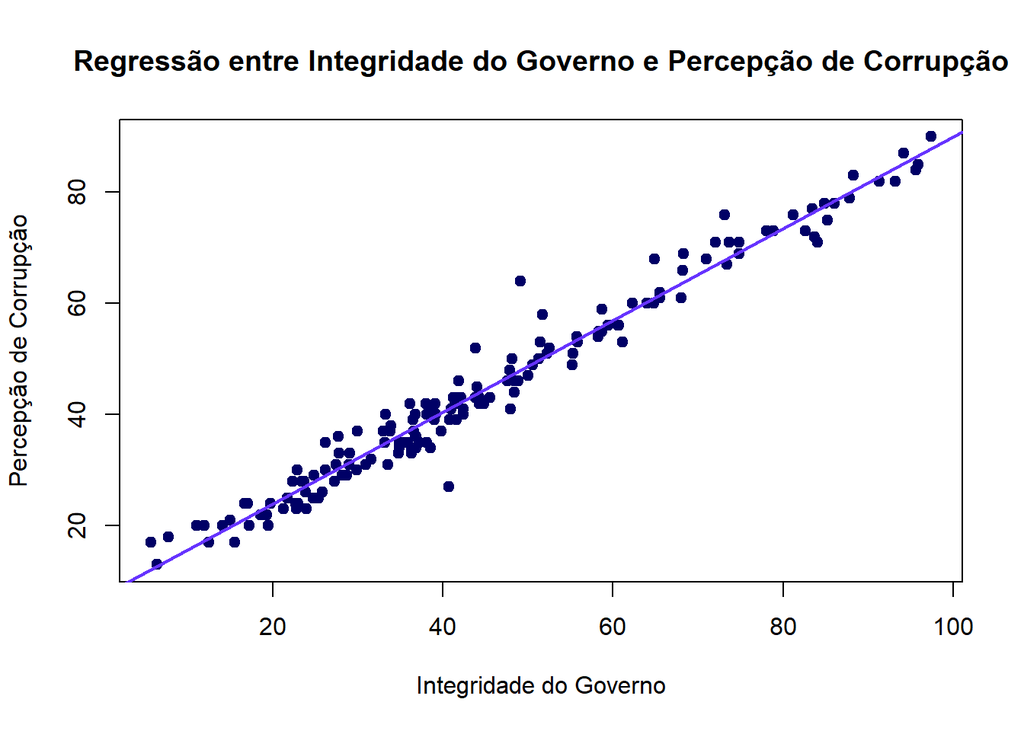

Correlações

O trecho abaixo cria uma nova base agregada por regiões e pela a média de ambos os índices de cada região

```r
# Cria a base com os dados do CPI
dados_região <- dados %>%
  group_by(region) %>%
  summarise(media_CPI = mean(corruption_perception_index, na.rm = TRUE)) %>%
  arrange(desc(media_CPI))

# Adiciona os dados de liberdade econômica
dados_região <- dados_região %>%
  left_join(dados %>%
      group_by(region) %>%
      summarise(media_Overall = mean(overall_score, na.rm = TRUE)) , by = "region")

# Exibe os dados
dados_região
```

```
## # A tibble: 5 × 3
##   region                   media_CPI media_Overall
##   <chr>                        <dbl>         <dbl>
## 1 Europe                        58.0          67.4
## 2 Middle East/North Africa      43.9          57.4
## 3 Asia-Pacific                  43.5          58.7
## 4 Americas                      41.6          57.7
## 5 Sub-Saharan Africa            34.0          52.4
```

O trecho abaixo plota um gráfico de barras de cada região, comparando o CPI e a liberdade econômica de cada região agregada.

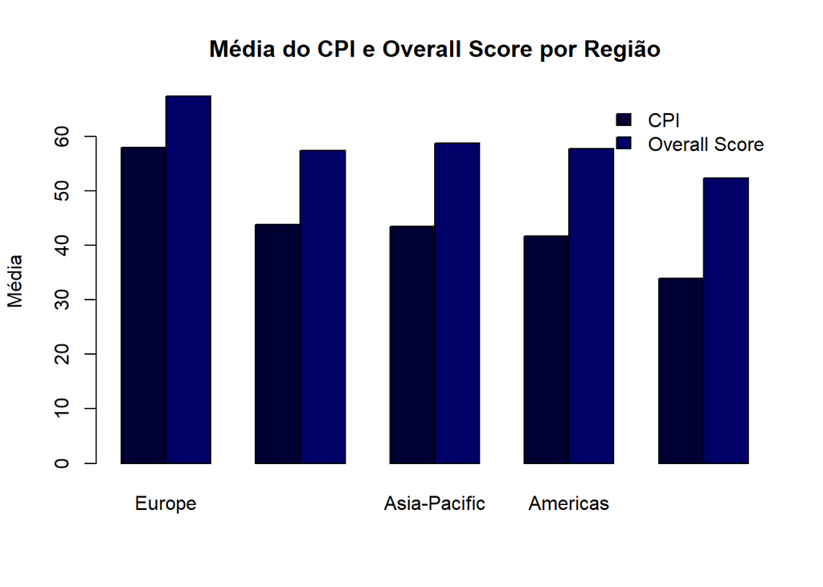

```r
# Trecho inpirado em: https://r-graph-gallery.com/barplot.html, 20 de setembro de 2024
matriz <- as.matrix(dados_região[, c("media_CPI", "media_Overall")])

barplot(height=t(matriz), names=dados_região$region ,
        col = c("#000033", "#000066"),  # Definir as cores para CPI e Overall Score
        beside = TRUE,  # Colocar as barras lado a lado
        main = "Média do CPI e Overall Score por Região",  # Título do gráfico
        ylab = "Média",  # Rótulo do eixo Y
        legend.text = c("CPI", "Overall Score"),  # Texto da legenda
        args.legend = list(x = "topright", bty = "n"))  # Posicionar a legenda
```